# Assignment1

Olwyn Byrne 21253074 Assignment 1 - House Price Data -Cross Validated k-nearest neighbour model

Introduction: We want to predict and compare house prices in an area of London using the same size floor area and discuss the results. We used the cross validated k nearest neighbour model to predict the house prices. K nearest neighbour is a supervised learning algorithm. It classifies new data points based on their position to nearby or neighbouring data points. This is a suitable model to use as we will be looking at each house's neighbours and using the average price of a number (k) of neighbours to predict the price of that house. Looking at the price of neighbouring houses would be one of the main indicators used in real life real estate valuations, so it is easy to interpret.

Method:

Running the Machine Learning Algorithm:

We used a Pipeline object to work like a regression model. Pipelines have fit and predict methods which are convenient as they contain the whole process including rescaling. We imported the pipeline function and specified the actual pipeline which is stored in object pipe. The arguments are blocks consisting of a string name and an object, which is regression or transformation. The pipeline can have several blocks with a fit method and all but the last has a transform method. The fit method of the pipeline uses the fit method of the first block and applies transform to the input data, this is then fed to the fit method of the next block and so on until it uses the predict method from the final block to get a prediction. We fit the model using unscaled data and then we used GridSearchCV a cross validation grid search and fit the model again. We applied our algorithm to easting and northing points in London. We used the meshgrid function with a specified range and created a grid of 100 by 100 points. We were required to “unravel” each variable into a single dimensional array so they could be read like a matrix. We could now use the predict method and the reshape method to get the house prices back in grid format. We then plotted as 3-D using a mean floor area. We created a function to automate the surface drawing so now we can use it with alternative floor areas – 75, 125 and 250 square metres.

```python
import numpy as np
import pandas as pd
import matplotlib as mpl

%matplotlib inline
mpl.rcParams['figure.figsize']= (15,10) #this increases inline figure size
```

```python
hp = pd.read_csv('hpdemo.csv', dtype=float) #read in data file
```

```python
price = hp['price']/1000.0
```

```python
#import pipeline function

from sklearn.pipeline import Pipeline
from sklearn.preprocessing import StandardScaler
from sklearn.neighbors import KNeighborsRegressor as NN
```

```python
#specify the actual pipeline, which is stored in object pipe

pipe= Pipeline([('zscores', StandardScaler()),('NNreg', NN(n_neighbors=6, weights='uniform', p=2))])
```

```python
#fit the model
pipe.fit(hp[['east','north','fl_area']],price)
```

```
Pipeline(steps=[('zscores', StandardScaler()),
                ('NNreg', KNeighborsRegressor(n_neighbors=6))])
```

```python
#prediction step using unscaled data
print(pipe.predict([[523800.0, 179750.0, 55.0]]))
```

```
[128.5]
```

```python
#Scoring

from sklearn.metrics import mean_absolute_error, make_scorer
mae = make_scorer(mean_absolute_error, greater_is_better=False)
```

```python
#Cross Validation GridSearch is specified

from sklearn.model_selection import GridSearchCV
```

```python
#using pipelines with GridSearchCV

pipe = Pipeline([('zscores',StandardScaler()),('NNreg',NN())])

opt_nn2 = GridSearchCV(
    estimator = pipe,
    scoring = mae,
    param_grid = {
        'NNreg__n_neighbors':range(1,35),
        'NNreg__weights':['uniform','distance'],
        'NNreg__p':[1,2]})
```

```python
#pipe is redefined without parametres, as these are chosen in gridsearch
#fit model again

opt_nn2.fit(hp[['east','north','fl_area']],price)
```

```
GridSearchCV(estimator=Pipeline(steps=[('zscores', StandardScaler()),
                                       ('NNreg', KNeighborsRegressor())]),
             param_grid={'NNreg__n_neighbors': range(1, 35), 'NNreg__p': [1, 2],
                         'NNreg__weights': ['uniform', 'distance']},
             scoring=make_scorer(mean_absolute_error, greater_is_better=False))
```

```python
#predictions can be made based on the best parametre combination
print(opt_nn2.predict([[523800.0, 179750.0, 55.0]]))
```

```
[122.53520623]
```

```python
#function for summary

def print_summary2(opt_pipe_object):
    params = opt_pipe_object.best_estimator_.get_params()
    score = - opt_pipe_object.best_score_
    print("Nearest neighbours: %8d" % params['NNreg__n_neighbors'])
    print("Minkowski p       : %8d" % params['NNreg__p'])
    print("Weighting         : %8s" % params['NNreg__weights'])
    print("MAE Score         : %8.2f" % score)
    return
```

```python
#optimal pipeline can be seen
print_summary2(opt_nn2)
```

```
Nearest neighbours:       16
Minkowski p       :        1
Weighting         : distance
MAE Score         :    26.42
```

```python
#create grid of 100 by 100 points
#eastings range 505000 to 555800
#northings range 158400 to 199900

east_mesh, north_mesh = np.meshgrid(np.linspace(505000,555800,100), np.linspace(158400,199900,100))
```

```python
#create grid for floor area, average level is used

#first create a new array same shape as eastings but contains zeros
fl_mesh = np.zeros_like(east_mesh)

#assign every element of the array with average floor size
fl_mesh[:,:] = np.mean(hp['fl_area'])
```

```python
#unravel the three 2-D arrays into single dimensional arrays
grid_predictor_vars = np.array([east_mesh.ravel(), north_mesh.ravel(),fl_mesh.ravel()]).T
```

```python
#these can now be used in the predict method
hp_pred = opt_nn2.predict(grid_predictor_vars)
```

```python
#reshape the array back to grid format

hp_mesh = hp_pred.reshape(east_mesh.shape)
```

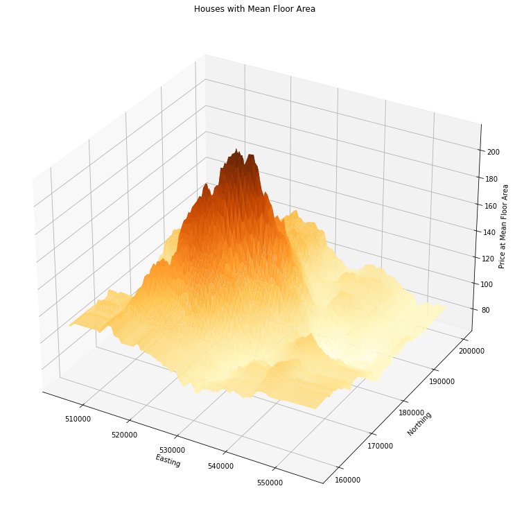

```python
#plot predicted house prices for house with mean floor area
import pylab as pl
from mpl_toolkits.mplot3d import Axes3D

fig = pl.figure()
ax = Axes3D(fig)

ax.plot_surface(east_mesh, north_mesh, hp_mesh, rstride=1, cstride=1, cmap='YlOrBr',lw=0.01)
ax.set_title('Houses with Mean Floor Area')

ax.set_xlabel('Easting')
ax.set_ylabel('Northing')
ax.set_zlabel('Price at Mean Floor Area')
pl.show()
```

```python
#create function to automate surface drawing
#this takes a pipeline and fixed floor area level
#this can then be used with alternative floor area values

def surf3d(pipe_model,fl_area):
    east_mesh, north_mesh = np.meshgrid(
        np.linspace(505000,555800,100),
        np.linspace(158400,199900,100))
    fl_mesh = np.zeros_like(east_mesh)
    fl_mesh[:,:] = fl_area
    grid_predictor_vars = np.array([east_mesh.ravel(),north_mesh.ravel(),fl_mesh.ravel()]).T
    hp_pred = pipe_model.predict(grid_predictor_vars)
    hp_mesh = hp_pred.reshape(east_mesh.shape)
    fig = pl.figure()
    ax = Axes3D(fig)
    ax.plot_surface(east_mesh, north_mesh, hp_mesh, rstride=1, cstride=1, cmap='YlOrBr',lw=0.01)

    ax.set_title(fl_area)

    ax.set_xlabel('Easting')
    ax.set_ylabel('Northing')
    ax.set_zlabel('Price at Floor Area')
    #pl.show()
    return
```

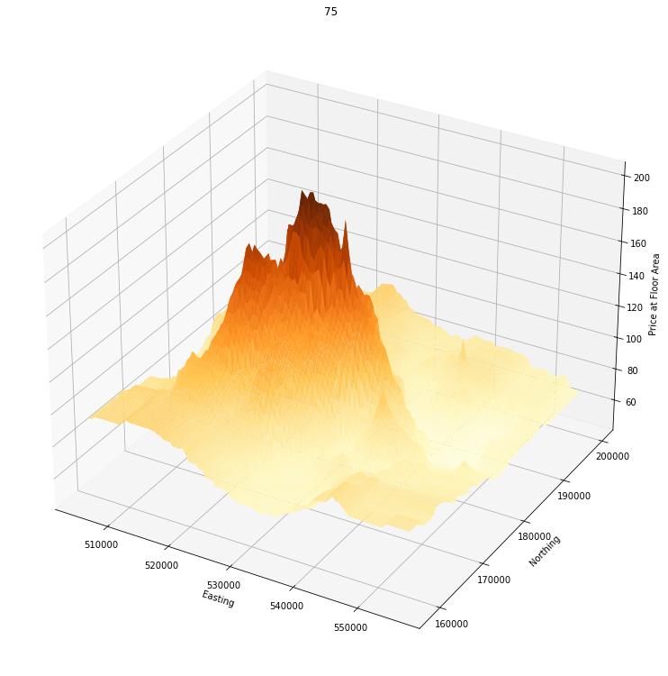

```python
#Use 75 for floor area

pl.close()
surf3d(opt_nn2,75)
pl.show()
```

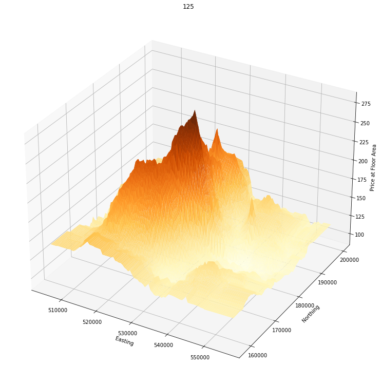

```python
#Use 125 for floor area
pl.close()
surf3d(opt_nn2,125)
pl.show()
```

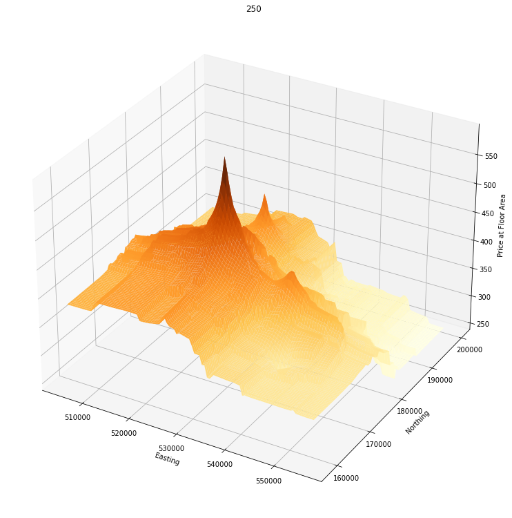

```python
#Use 250 for floor area


pl.close()
surf3d(opt_nn2,250)
pl.show()
```

Results:

Mean Floor Area Graph:

This surface area graph is quite uneven. There is a large dark peak near the centre and some smaller peaks of differing heights and colour surrounding it. Most of the edges are quite flat, some have slight rippling. All the edges indicate a low price for the properties located there. The properties with highest value are to the centre left, indicated by the large dark peak. I understand from this graph that generally the further away from this main peak the cheaper the houses.

75 Square Metres Graph:

This graph is very uneven. Most of the action is to the left and left centre. The right side of the graph is very flat. It looks less symmetrical than the previous graph. There are many tall peaks in the centre and smaller ones to the left. The higher priced houses are indicated by the position and colour of the peaks. The left-hand side of the graph, specifically centre left holds the most expensive houses. The right side and edges show the cheapest houses.

250 Square Metres Graph:

This data is very evenly distributed apart from a few small sharp peaks. The peaks are not as dramatic as the previous graphs. The edges are not as flat the other graphs. It looks like the price of this sized house is quite consistent. The three small sharp peaks may be spatial outliers. The cheapest houses of this size are to the right edge.

Conclusions:

In conclusion we can say that location has a much bigger impact on the predicted price of smaller houses. We predict the largest size house will get a similar price wherever it is located, apart from a couple of specific areas. The smaller houses have predicted higher prices in one main area and outside of this have much lower predicted prices. This makes sense if you consider a small apartment in the centre of a city would be very desirable but if you didn't have the amenities of the city centre on your doorstep then it may not be so desirable and therefore you may not pay as much for it.

The houses with 125 square metres are priced more similarly than the smaller houses but there are still distinct areas where they do not price well. The mean floor area graph is aligned between the 75 square metre graph and the 125 square metre graph, so I would guess the mean square metre is around 100 for these houses.

All the graphs show a peak around a similar area, centre left, so this is obviously a very expensive part of London, whatever size your house is. They all also show very low prices in a similar area too, to the right of the graphs, which must be a very inexpensive or undesirable place to buy.